# prior_predictive_check

### library load

```r
library(tidyverse)
library(glue)
```

```r
library(tidybayes)
library(cowplot)
library(scales)
theme_set(theme_cowplot())

load_existing_sim <- TRUE
```

I’m starting this prior check with the work I’ve already done in the sandbox. In those scripts I already got a sense of what weakly informative priors for my starting model might be. In those files, I only did a visual inspection of the prior predictive distribution, not neccesarily including any summary statistics. I also did not do any sort of checks based on the sample size of the small design I have.

### model

Written down the model is:

$$\begin{aligned}
\mathrm{-likelihood-} \\
error_i &\sim (1-p\_guess_i)*VM(0, \kappa_i) + (p\_guess_i)*Unif(-\pi,\pi) \\
\\
\mathrm{-param~transformation-} \\
\kappa_i &= sd2k(circ\_sd_i) \\
\\
\mathrm{-linear~model-} \\
circ\_sd_i &= exp(\alpha_{0,SUBJ[i]} + \alpha_{\Delta,SUBJ[i]} * postCond) ~~ \mathrm{-log~link~on~sd-} \\
p\_guess_i &= inv\_logit(\beta_{0,SUBJ[i]} + \beta_{\Delta,SUBJ[i]} * postCond) ~~ \mathrm{-logit~link~on~p\_guess-} \\
\\
\mathrm{-priors:~all~independent-}\\
\alpha_{0,SUBJ[...]} &\sim Normal(mu\_\alpha_0, sigma\_\alpha_0) \\
\alpha_{\Delta,SUBJ[...]} &\sim Normal(mu\_\alpha_{\Delta}, sigma\_\alpha_{\Delta}) \\
\beta_{0,SUBJ[...]} &\sim Normal(mu\_\beta_0, sigma\_\beta_0) \\
\beta_{\Delta,SUBJ[...]} &\sim Normal(mu\_\beta_{\Delta}, sigma\_\beta_{\Delta}) \\
\\
mu\_\alpha_0 &\sim Normal(4, 0.5)\\
sigma\_\alpha_0 &\sim Normal^+(0, 0.5) \\
mu\_\alpha_{\Delta} &\sim Normal(0, 0.5)\\
sigma\_\alpha_{\Delta} &\sim Normal^+(0, 0.5)\\
mu\_\beta_0 &\sim Normal(0, 1.5)\\
sigma\_\beta_0 &\sim Normal^+(0, 1.5)\\
mu\_\beta_{\Delta} &\sim Normal(0, 1)\\
sigma\_\beta_{\Delta} &\sim Normal^+(0, 1)\\
\end{aligned}$$

### real obs load

I am considering the color stimulation data. samples sizes:

```r
obs_data <- read_csv('../data/stimulation_obvs.csv')
#summarize subj num, obs count, and obs condition split
(subj_summary <- obs_data %>%
  group_by(subj_index) %>%
  summarise(n_obs = n(), frac_stim = mean(stimulation)))
```

```
## # A tibble: 2 x 3
##   subj_index n_obs frac_stim
##        <dbl> <int>     <dbl>
## 1          1   252       0.5
## 2          2   252       0.5
```

2 subjs with 252 observations each, 126 per condition.

9/12 - I am thinking I should simulate varying effects using the actual samples sizes I have. I also think that this shouldnt matter (at least for a model like this). I’ll also try with a larger number of subjects.

```r
nsubj_sim <- 15
nobs_per_cond_sim <- 126
```

### Simulation

functions

```r
# this function takes a single set of parameters and covariates and simlates an observation from the mixture model
simulateData_likelihood <- function(subj_alpha0,
                                    subj_alphaD,
                                    subj_beta0,
                                    subj_betaD,
                                    stimulation){

    # calculate the delinked mixing proportion
    pMem_linked <- subj_beta0 + (subj_betaD * stimulation)
    pMem <- exp(pMem_linked)/(1 + exp(pMem_linked))

    # which part of the mixture does this obs come from
    memFlip <- rbernoulli(1, pMem)

    obs <- NA

    if (memFlip == 1){
      obs <- Rfast::rvonmises(1, pi, exp(subj_alpha0 + (subj_alphaD*stimulation))) - pi
    }else{
      obs <- runif(1, -pi, pi)
    }

    obs_tibble <- tibble(obs_radian = obs, obs_degree = pracma::rad2deg(obs))

    return(obs_tibble)

}

simulateData_subj <- function(subj_alpha0, subj_alphaD, subj_beta0, subj_betaD, nobs_per_condition){

    conditions <- c(0,1)

    subj_data <- tibble(
      subj_alpha0 = subj_alpha0,
      subj_alphaD = subj_alphaD,
      subj_beta0 = subj_beta0,
      subj_betaD = subj_betaD,
      stimulation = rep(conditions, each = nobs_per_condition)
    )

    subj_data <- subj_data %>%
      mutate(subj_obs = pmap(subj_data, simulateData_likelihood)) %>%
      select(-c(subj_alpha0, subj_alphaD, subj_beta0, subj_betaD)) %>%
      unnest(subj_obs)

    return(subj_data)
}

# this function will take a single set of simulated parameter draws and then simulate an implied data set
simulateData <- function(sim_num,
                         alpha0_mu, alpha0_sigma,
                         alphaD_mu, alphaD_sigma,
                         beta0_mu, beta0_sigma,
                         betaD_mu, betaD_sigma,
                         nsubj = 100, nobs_per_condition = 100){

  print(glue("simulation: {sim_num}"))

  # generate lower level subject-specific parameters
  sim_subj_alpha0 <- rnorm(nsubj, alpha0_mu, alpha0_sigma)
  sim_subj_alphaD <- rnorm(nsubj, alphaD_mu, alphaD_sigma)

  sim_subj_beta0 <- rnorm(nsubj, beta0_mu, beta0_sigma)
  sim_subj_betaD <- rnorm(nsubj, betaD_mu, betaD_sigma)

  sim_data <- tibble(
         subj = 1:nsubj,
         subj_alpha0 = sim_subj_alpha0,
         subj_alphaD = sim_subj_alphaD,
         subj_beta0 = sim_subj_beta0,
         subj_betaD = sim_subj_betaD,
         nobs_per_condition = nobs_per_condition
         )

  sim_data <- sim_data %>%
    mutate(subj_obs = pmap(sim_data %>% select(-subj), simulateData_subj))

  return(sim_data)
}
```

run simulate

```r
found_existing_sim <- FALSE
if (file.exists("sim_datasets.rds")){
  found_existing_sim <- TRUE
}


if (load_existing_sim == FALSE || found_existing_sim == FALSE){

  nsim_datasets <- 1000

  sim_priors <- tibble(
    sim_num = 1:nsim_datasets,
    alpha0_mu = rnorm(nsim_datasets, 4, 0.5),
    alpha0_sigma = abs(rnorm(nsim_datasets, 0, 0.5)),
    alphaD_mu =  rnorm(nsim_datasets, 0, 0.5),
    alphaD_sigma = abs(rnorm(nsim_datasets, 0, 0.5)),
    beta0_mu = rnorm(nsim_datasets, 0, 1.5),
    beta0_sigma = abs(rnorm(nsim_datasets, 0, 1.5)),
    betaD_mu = rnorm(nsim_datasets, 0, 1),
    betaD_sigma = abs(rnorm(nsim_datasets, 0, 1)),
    nsubj = nsubj_sim,
    nobs_per_cond = nobs_per_cond_sim
  )

  sim_datasets <- sim_priors %>%
    mutate(dataset = pmap(sim_priors, simulateData))

  saveRDS(sim_datasets, file = "sim_datasets.rds")

}else{

  sim_datasets <- readRDS("sim_datasets.rds")
}
```

Check sim data

```r
head(sim_datasets)
```

```
## # A tibble: 6 x 12
##   sim_num alpha0_mu alpha0_sigma alphaD_mu alphaD_sigma beta0_mu
##     <int>     <dbl>        <dbl>     <dbl>        <dbl>    <dbl>
## 1       1      3.40        1.03    -0.193         1.33    -1.68
## 2       2      3.74        0.126    0.316         0.141    0.859
## 3       3      3.83        0.318    0.177         0.357   -1.76
## 4       4      3.35        0.283   -0.497         0.443   -0.734
## 5       5      4.03        0.396    0.0410        0.497    0.899
## 6       6      4.01        0.223    0.827         0.846   -2.02
## # … with 6 more variables: beta0_sigma <dbl>, betaD_mu <dbl>,
## #   betaD_sigma <dbl>, nsubj <dbl>, nobs_per_cond <dbl>, dataset <list>
```

```r
head(sim_datasets$dataset[[1]])
```

```
## # A tibble: 6 x 7
##    subj subj_alpha0 subj_alphaD subj_beta0 subj_betaD nobs_per_condit…
##   <int>       <dbl>       <dbl>      <dbl>      <dbl>            <dbl>
## 1     1        1.97      -0.406     -1.94      0.419               126
## 2     2        2.82       0.547     -1.91      0.321               126
## 3     3        3.40      -0.834     -2.07      0.0834              126
## 4     4        2.99      -3.04      -0.845     0.156               126
## 5     5        2.36       2.38      -1.74      0.562               126
## 6     6        3.82       0.570     -0.742     0.514               126
## # … with 1 more variable: subj_obs <list>
```

```r
head(sim_datasets$dataset[[1]]$subj_obs[[1]])
```

```
## # A tibble: 6 x 3
##   stimulation obs_radian obs_degree
##         <dbl>      <dbl>      <dbl>
## 1           0    -2.32      -133.
## 2           0     1.26        72.4
## 3           0    -0.0817      -4.68
## 4           0    -2.62      -150.
## 5           0    -0.0748      -4.28
## 6           0     2.93       168.
```

### Plot distributions and summary statistics

Ideas:

Definitely plot the priors on the intercept and slope means, transformed back into sd

plot the prior predicitive densities for subjects

Some other plot ideas:

shaded histogram plot, combining data across stimulation conditions - check if data looks too peaked or too flat

shaded histogram plot, one for each stimulation condition - same check ^

plot of density lines, one from each sim dataset, one with both conditions and one with them split out - this would help identify weird distribution more that shaded histogram perhaps

### Prior distribution on von-mises circSD, linear model parameters (pre group mean, post group mean, post-pre mean change)

No accounting for subject variance here

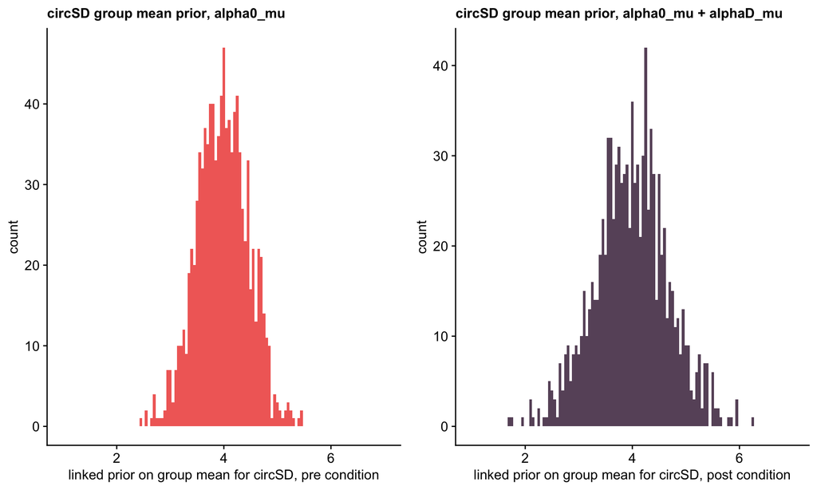

```r
##
## alpha0_mu
##

## linked prior distribution
alpha0_mu_hist <- sim_datasets %>%
  ggplot(aes(x = alpha0_mu)) +
  geom_histogram(binwidth = 0.05, fill = "#F16C66") +
  theme(legend.position = "none",
        axis.title = element_text(size = 12),
        plot.title = element_text(size = 12)) +
  labs(x = "linked prior on group mean for circSD, pre condition",
       title = "circSD group mean prior, alpha0_mu") +
  scale_x_continuous(limits = c(1,7))


##
## alpha0_mu + alphaD_mu = alpha1_mu
##

## linked prior distribution
alpha1_mu_hist <- sim_datasets %>%
  transmute(alpha1_mu = alpha0_mu + alphaD_mu) %>%
  ggplot(aes(x = alpha1_mu)) +
  geom_histogram(binwidth = 0.05, fill = "#685369") +
  theme(axis.title = element_text(size = 12),
        plot.title = element_text(size = 12)) +
  labs(x = "linked prior on group mean for circSD, post condition",
       title = "circSD group mean prior, alpha0_mu + alphaD_mu") +
  scale_x_continuous(limits = c(1,7))


plot_grid(alpha0_mu_hist, alpha1_mu_hist, nrow = 1, align = "h")
```

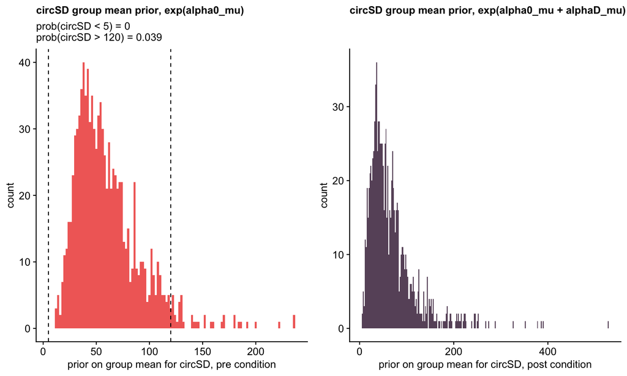

```r
##
## alpha0_mu
##

## delinked prior alpha0_mu
alpha0_mu_delinked_stats <- sim_datasets %>%
  transmute(delinked = exp(alpha0_mu)) %>%
  summarise(less_than_5 = sum(delinked < 5)/n(), greater_than_120 = sum(delinked > 120)/n())

alpha0_mu_delinked_hist <- sim_datasets %>%
  transmute(delinked = exp(alpha0_mu)) %>%
  ggplot(aes(x = delinked)) +
  geom_histogram(binwidth = 2, fill = "#F16C66") +
  geom_vline(xintercept = c(5, 120), linetype = "dashed") +
  labs(x = "prior on group mean for circSD, pre condition",
       title = "circSD group mean prior, exp(alpha0_mu)",
       subtitle = glue("prob(circSD < 5) = {alpha0_mu_delinked_stats$less_than_5}\nprob(circSD > 120) = {alpha0_mu_delinked_stats$greater_than_120}")) +
  theme(axis.title = element_text(size = 12),
        plot.title = element_text(size = 12))

##
## alpha0_mu + alphaD_mu = alpha1_mu
##

## delinked prior alpha0_mu + alphaD_mu
alpha1_mu_delinked_hist <- sim_datasets %>%
  transmute(delinked = exp(alpha0_mu + alphaD_mu)) %>%
  ggplot(aes(x = delinked)) +
  geom_histogram(binwidth = 2, fill = "#685369") +
  labs(x = "prior on group mean for circSD, post condition",
       title = "circSD group mean prior, exp(alpha0_mu + alphaD_mu)") +
  theme(axis.title = element_text(size = 12),
        plot.title = element_text(size = 12))


plot_grid(alpha0_mu_delinked_hist, alpha1_mu_delinked_hist, nrow = 1, align = "h")
```

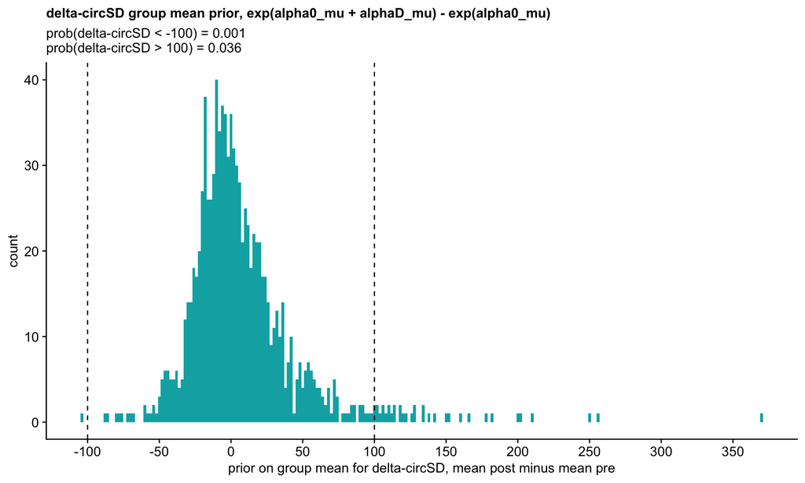

```r
##
## exp(alpha0_mu + alphaD_mu) - exp(alpha0_mu) plot
##

alphaD_mu_delinked_stats <- sim_datasets %>%
  transmute(delinked = exp(alpha0_mu + alphaD_mu) - exp(alpha0_mu)) %>%
  summarise(less_than_n100 = sum(delinked < -100)/n(), greater_than_100 = sum(delinked > 100)/n())

alphaD_mu_delinked_hist <- sim_datasets %>%
  transmute(delinked = exp(alpha0_mu + alphaD_mu) - exp(alpha0_mu)) %>%
  ggplot(aes(x = delinked)) +
  geom_histogram(binwidth = 2, fill = "#00AEB2") +
  geom_vline(xintercept = c(-100, 100), linetype = "dashed") +
  labs(x = "prior on group mean for delta-circSD, mean post minus mean pre",
       title = "delta-circSD group mean prior, exp(alpha0_mu + alphaD_mu) - exp(alpha0_mu)",
       subtitle = glue("prob(delta-circSD < -100) = {alphaD_mu_delinked_stats$less_than_n100}\nprob(delta-circSD > 100) = {alphaD_mu_delinked_stats$greater_than_100}")) +
  theme(axis.title = element_text(size = 12),
        plot.title = element_text(size = 12)) +
  scale_x_continuous(breaks= pretty_breaks(10))

alphaD_mu_delinked_hist
```

All these for the prior on circSD mean parameters look good.

### Prior predicitive distribution on subject effects on circSD (based on simulated subjects from each dataset)

These plots indicate the effects of the priors on `alpha0_mu`, `alpha0_sigma`, `alphaD_mu`, `alphaD_sigma`.

```r
sim_subj_circSD_hist_count <- function(dataset, max_val = 120){

  pre_circSD <- exp(dataset$subj_alpha0)
  post_circSD <- exp(dataset$subj_alpha0 + dataset$subj_alphaD)

  pre_circSD[pre_circSD > max_val] <- max_val
  post_circSD[post_circSD > max_val] <- max_val

  breaks <- seq(0, ceiling(max(c(pre_circSD, post_circSD)) / 10 ) * 10 ,10)

  pre_circSD_bincount <- hist(pre_circSD, breaks = breaks, plot = FALSE)$counts
  post_circSD_bincount <- hist(post_circSD, breaks = breaks, plot = FALSE)$counts

  pre_circSD_bincount_names <- glue("pre_circSD_c{breaks[-1]}")
  post_circSD_bincount_names <- glue("post_circSD_c{breaks[-1]}")

  bincounts <- tibble(ct = c(pre_circSD_bincount, post_circSD_bincount),
                      ct_name = c(pre_circSD_bincount_names, post_circSD_bincount_names))

  return(bincounts)

}


sim_datasets %>%
  select(sim_num, dataset) %>%
  mutate(subj_hist_counts = map(dataset, sim_subj_circSD_hist_count)) %>%
  unnest(subj_hist_counts) %>%
  pivot_wider(names_from = ct_name, values_from = ct) %>%
  replace(is.na(.), 0) %>% head()
  select(-c(sim_num, dataset)) %>%
  mutate(quants = map(everything(), ~quantile(., probs = seq(0.1, 0.9, 0.1)))) %>%
  unnest(quants) %>% head
```

[output not shown]

Calculate min and max subject pre, post, and circSD effect size in each simulation.

```r
sim_subj_extremes <- sim_datasets %>%
  unnest(dataset) %>%
  mutate(subj_alpha1 = subj_alpha0 + subj_alphaD,
         subj_alpha0_delinked = exp(subj_alpha0),
         subj_alpha1_delinked = exp(subj_alpha1),
         subj_circSD_effect = subj_alpha1_delinked - subj_alpha0_delinked ) %>%
  group_by(sim_num) %>%
  summarize_at(vars(subj_alpha0_delinked, subj_alpha1_delinked, subj_circSD_effect), list(max = max, min = min))
```

##### Across-sim max pre condition circSD

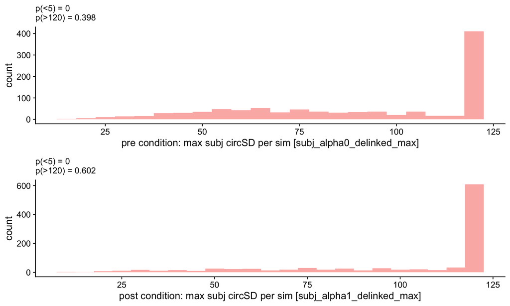

```r
#What is the max subject pre condition value in each dataset
pre_plot <- sim_subj_extremes %>%
  mutate(subj_alpha0_delinked_max = if_else(subj_alpha0_delinked_max > 120, 120, subj_alpha0_delinked_max)) %>%
  ggplot() +
  geom_histogram(aes(x = subj_alpha0_delinked_max, fill = "red", alpha = 0.3), binwidth = 5) +
  theme(legend.position = "none") +
  labs(x = "pre condition: max subj circSD per sim [subj_alpha0_delinked_max]",
       subtitle = glue("p(<5) = {sum(sim_subj_extremes$subj_alpha0_delinked_max < 5)/length(sim_subj_extremes$subj_alpha0_delinked_max)}\n p(>120) = {sum(sim_subj_extremes$subj_alpha0_delinked_max > 120)/length(sim_subj_extremes$subj_alpha0_delinked_max)}"))

#What is the max subject post condition value in each dataset
post_plot <- sim_subj_extremes %>%
  mutate(subj_alpha1_delinked_max = if_else(subj_alpha1_delinked_max > 120, 120, subj_alpha1_delinked_max)) %>%
  ggplot() +
  geom_histogram(aes(x = subj_alpha1_delinked_max, fill = "red", alpha = 0.3), binwidth = 5) +
  theme(legend.position = "none") +
  labs(x = "post condition: max subj circSD per sim [subj_alpha1_delinked_max]",
       subtitle = glue("p(<5) = {sum(sim_subj_extremes$subj_alpha1_delinked_max < 5)/length(sim_subj_extremes$subj_alpha1_delinked_max)}\n p(>120) = {sum(sim_subj_extremes$subj_alpha1_delinked_max > 120)/length(sim_subj_extremes$subj_alpha1_delinked_max)}"))


plot_grid(pre_plot, post_plot, ncol =1, align = 'v')
```

This looks horrible. circSD should rarely go above 120.

##### Across-sim min pre condition circSD

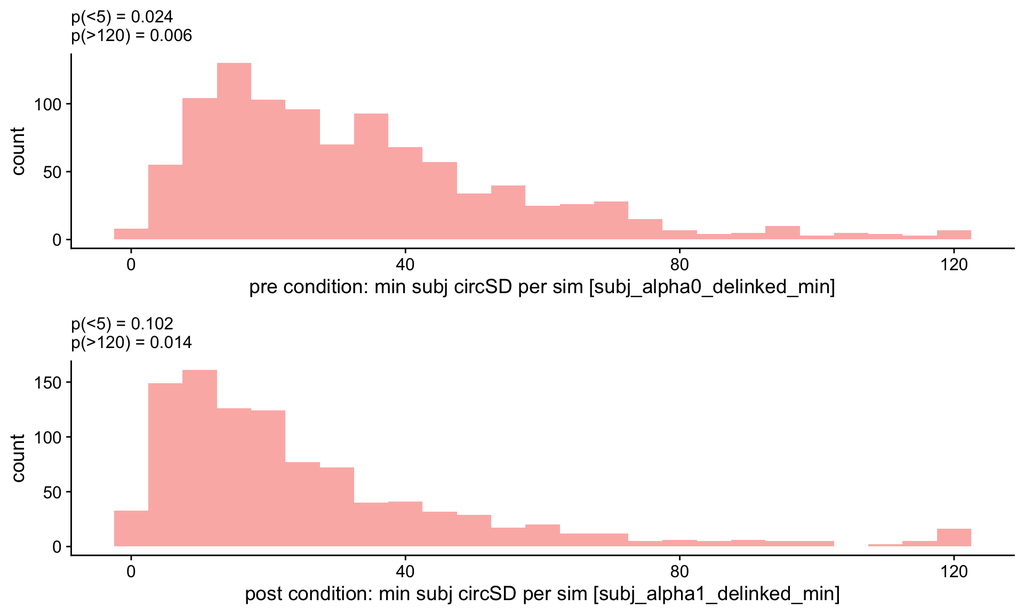

```r
pre_plot <- sim_subj_extremes %>%
  mutate(subj_alpha0_delinked_min = if_else(subj_alpha0_delinked_min > 120, 120, subj_alpha0_delinked_min)) %>%
  ggplot() +
  geom_histogram(aes(x = subj_alpha0_delinked_min, fill = "red", alpha = 0.3), binwidth = 5) +
  theme(legend.position = "none") +
  labs(x = "pre condition: min subj circSD per sim [subj_alpha0_delinked_min]",
       subtitle = glue("p(<5) = {sum(sim_subj_extremes$subj_alpha0_delinked_min < 5)/length(sim_subj_extremes$subj_alpha0_delinked_min)}\n p(>120) = {sum(sim_subj_extremes$subj_alpha0_delinked_min > 120)/length(sim_subj_extremes$subj_alpha0_delinked_min)}"))

#What is the most extreme subject post condition value in each dataset
post_plot <- sim_subj_extremes %>%
  mutate(subj_alpha1_delinked_min = if_else(subj_alpha1_delinked_min > 120, 120, subj_alpha1_delinked_min)) %>%
  ggplot() +
  geom_histogram(aes(x = subj_alpha1_delinked_min, fill = "red", alpha = 0.3), binwidth = 5) +
  theme(legend.position = "none") +
  labs(x = "post condition: min subj circSD per sim [subj_alpha1_delinked_min]",
       subtitle = glue("p(<5) = {sum(sim_subj_extremes$subj_alpha1_delinked_min < 5)/length(sim_subj_extremes$subj_alpha1_delinked_min)}\n p(>120) = {sum(sim_subj_extremes$subj_alpha1_delinked_min > 120)/length(sim_subj_extremes$subj_alpha1_delinked_min)}"))


plot_grid(pre_plot, post_plot, ncol =1, align = 'v')
```

Things look OK from this point of view.

##### Across-sim max+min circSD effect size

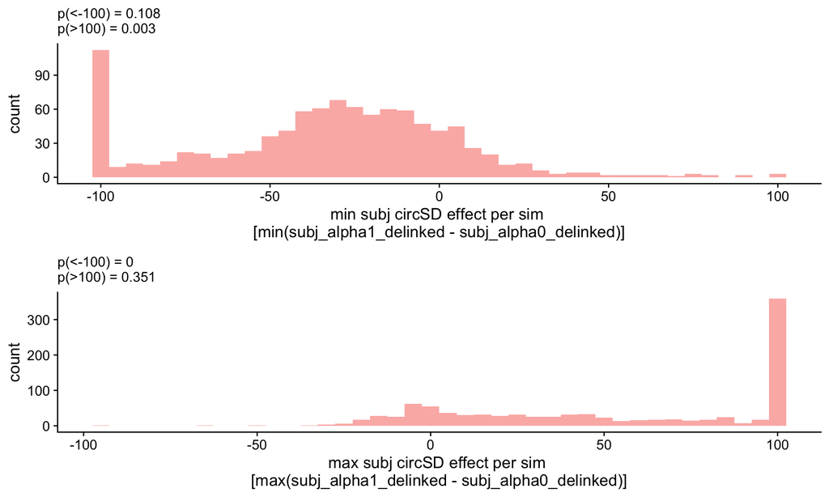

```r
#What is the most extreme change from pre to post in a subject

min_plot <- sim_subj_extremes %>%
  mutate(subj_circSD_effect_min = if_else(subj_circSD_effect_min > 100 , 100, subj_circSD_effect_min)) %>%
  mutate(subj_circSD_effect_min = if_else(subj_circSD_effect_min < -100 , -100, subj_circSD_effect_min)) %>%
  ggplot() +
  geom_histogram(aes(x = subj_circSD_effect_min, fill = "red", alpha = 0.3), binwidth = 5) +
  theme(legend.position = "none") +
  labs(x = "min subj circSD effect per sim \n[min(subj_alpha1_delinked - subj_alpha0_delinked)]",
       subtitle = glue("p(<-100) = {sum(sim_subj_extremes$subj_circSD_effect_min < -100)/length(sim_subj_extremes$subj_circSD_effect_min)}\n p(>100) = {sum(sim_subj_extremes$subj_circSD_effect_min > 100)/length(sim_subj_extremes$subj_circSD_effect_min)}"))

#What is the most extreme subject post condition value in each dataset
max_plot <- sim_subj_extremes %>%
  mutate(subj_circSD_effect_max = if_else(subj_circSD_effect_max > 100 , 100, subj_circSD_effect_max)) %>%
  mutate(subj_circSD_effect_max = if_else(subj_circSD_effect_max < -100 , -100, subj_circSD_effect_max)) %>%
  ggplot() +
  geom_histogram(aes(x = subj_circSD_effect_max, fill = "red", alpha = 0.3), binwidth = 5) +
  theme(legend.position = "none") +
  labs(x = "max subj circSD effect per sim \n[max(subj_alpha1_delinked - subj_alpha0_delinked)]",
       subtitle = glue("p(<-100) = {sum(sim_subj_extremes$subj_circSD_effect_max < -100)/length(sim_subj_extremes$subj_circSD_effect_max)}\n p(>100) = {sum(sim_subj_extremes$subj_circSD_effect_max > 100)/length(sim_subj_extremes$subj_circSD_effect_max)}"))

plot_grid(min_plot, max_plot, ncol =1, align = 'v')
```

##### Dig deeper on circSD priors

Both the max pre/post subject distributions of circSD and the max/min subject effect size distributions on circSD contained too many extreme values.

Can I see which prior distributions I need to change in order to correct these by plotting the points from those distributions along with their respective prior distribution samples?

(Is this a useful technique in general?)

Plots:

for (max pre circSD, max post circSD, max circSD ES, min circSD ES) * vs alpha0_mu * vs alpha0_sigma * vs alphaD_mu * vs alphaD_sigma